# Hotel Reservations Data Analytics & Classification

## Mission: Predicting if a customer will cancel their reservation or not.

##### Dataset Description:

- Booking_ID: unique identifier of each booking
- no_of_adults: Number of adults
- no_of_children: Number of Children
- no_of_weekend_nights: Number of weekend nights (Saturday or Sunday) the guest stayed or booked to stay at the hotel
- no_of_week_nights: Number of week nights (Monday to Friday) the guest stayed or booked to stay at the hotel
- type_of_meal_plan: Type of meal plan booked by the customer:
- required_car_parking_space: Does the customer require a car parking space? (0 - No, 1- Yes)
- room_type_reserved: Type of room reserved by the customer. The values are ciphered (encoded) by INN Hotels.
- lead_time: Number of days between the date of booking and the arrival date
- arrival_year: Year of arrival date
- arrival_month: Month of arrival date
- arrival_date: Date of the month
- market_segment_type: Market segment designation.
- repeated_guest: Is the customer a repeated guest? (0 - No, 1- Yes)
- no_of_previous_cancellations: Number of previous bookings that were canceled by the customer prior to the current booking
- no_of_previous_bookings_not_canceled: Number of previous bookings not canceled by the customer prior to the current booking
- avg_price_per_room: Average price per day of the reservation; prices of the rooms are dynamic. (in euros)
- no_of_special_requests: Total number of special requests made by the customer (e.g. high floor, view from the room, etc)
- booking_status: Flag indicating if the booking was canceled or not.

# 1 | Importing Dataset & Libraries

```r
library(skimr)
library(ggplot2)
library(scales)
library(gridExtra)
library(waffle)
library(dplyr)
library(reshape2)
library(caret)
library(rpart)
library(rpart.plot)
library(randomForest)
custom_red <- "#f8766d"
custom_blue <- "#00bfc4"
```

```r
df <- read.csv("Hotel Reservations.csv")
head(df)
```

|  | Booking_ID | no_of_adults | no_of_children | no_of_weekend_nights | no_of_week_nights | type_of_meal_plan | required_car_parking_space | room_type_reserved | lead_time | arrival_year | arrival_month | arrival_date | market_segment_type | repeated_guest | no_of_previous_cancellations | no_of_previous_bookings_not_canceled | avg_price_per_room | no_of_special_requests | booking_status |
| --- | --- | --- | --- | --- | --- | --- | --- | --- | --- | --- | --- | --- | --- | --- | --- | --- | --- | --- | --- |
| 1 | INN00001 | 2 | 0 | 1 | 2 | Meal Plan 1 | 0 | Room_Type 1 | 224 | 2017 | 10 | 2 | Offline | 0 | 0 | 0 | 65.00 | 0 | Not_Canceled |
| 2 | INN00002 | 2 | 0 | 2 | 3 | Not Selected | 0 | Room_Type 1 | 5 | 2018 | 11 | 6 | Online | 0 | 0 | 0 | 106.68 | 1 | Not_Canceled |
| 3 | INN00003 | 1 | 0 | 2 | 1 | Meal Plan 1 | 0 | Room_Type 1 | 1 | 2018 | 2 | 28 | Online | 0 | 0 | 0 | 60.00 | 0 | Canceled |
| 4 | INN00004 | 2 | 0 | 0 | 2 | Meal Plan 1 | 0 | Room_Type 1 | 211 | 2018 | 5 | 20 | Online | 0 | 0 | 0 | 100.00 | 0 | Canceled |
| 5 | INN00005 | 2 | 0 | 1 | 1 | Not Selected | 0 | Room_Type 1 | 48 | 2018 | 4 | 11 | Online | 0 | 0 | 0 | 94.50 | 0 | Canceled |
| 6 | INN00006 | 2 | 0 | 0 | 2 | Meal Plan 2 | 0 | Room_Type 1 | 346 | 2018 | 9 | 13 | Online | 0 | 0 | 0 | 115.00 | 1 | Canceled |

# 2 | Data Cleaning

## 2.1 | Checking Null Values & Duplicated Rows

```r
duplicated_rows <- duplicated(df)
df[duplicated_rows, ]
```

| Booking_ID | no_of_adults | no_of_children | no_of_weekend_nights | no_of_week_nights | type_of_meal_plan | required_car_parking_space | room_type_reserved | lead_time | arrival_year | arrival_month | arrival_date | market_segment_type | repeated_guest | no_of_previous_cancellations | no_of_previous_bookings_not_canceled | avg_price_per_room | no_of_special_requests | booking_status |
| --- | --- | --- | --- | --- | --- | --- | --- | --- | --- | --- | --- | --- | --- | --- | --- | --- | --- | --- |

```r
df <- unique(df)
```

```r
dim(df)
```

```
[1] 36275    19
```

## 2.2 | Unique Values per Column

### 2.2.1 | Number of unique values per column (including categorical variables)

```r
sapply(df, function(x) length(unique(x)))
```

```
                          Booking_ID                         no_of_adults
                               36275                                    5
                      no_of_children                 no_of_weekend_nights
                                   6                                    8
                   no_of_week_nights                    type_of_meal_plan
                                  18                                    4
          required_car_parking_space                   room_type_reserved
                                   2                                    7
                           lead_time                         arrival_year
                                 352                                    2
                       arrival_month                         arrival_date
                                  12                                   31
                 market_segment_type                       repeated_guest
                                   5                                    2
        no_of_previous_cancellations no_of_previous_bookings_not_canceled
                                   9                                   59
                  avg_price_per_room               no_of_special_requests
                                3930                                    6
                      booking_status
                                   2
```

### 2.2.2 | Unique values for non-numerical columns:

```r
table(df$type_of_meal_plan)
```

```
 Meal Plan 1  Meal Plan 2  Meal Plan 3 Not Selected
       27835         3305            5         5130
```

```r
table(df$booking_status)
```

```
    Canceled Not_Canceled
       11885        24390
```

## 2.3 | Data Transformation

### 2.3.1 | Removing ID Column

```r
df <- subset(df, select = -Booking_ID)
```

### 2.3.2 | Transforming Target Column

Transforming the “booking_status” column to “canceled” and using Boolean variable types.

```r
names(df)[names(df) == "booking_status"] <- "canceled"
df$canceled <- ifelse(df$canceled == "Canceled", TRUE, FALSE)
```

Column type has been transformed to Logical, aka Boolean.

### 2.3.3 | Transforming Columns to Logical Type

Converting the “repeated_guest” and “required_car_parking_space” columns to Boolean variables.

```r
df$repeated_guest <- ifelse(df$repeated_guest == 1, TRUE, FALSE)
df$required_car_parking_space <- ifelse(df$required_car_parking_space == 1, TRUE, FALSE)
```

### 2.3.4 | Transforming Columns to Numerical Type

#### 2.3.4.1 | Room Type Reserved Column

Transforming the “room_type_reserved” column into an integer representation of room types by replacing “Room_Type” with an empty character using the gsub() function.

```r
df$room_type_reserved <- gsub("Room_Type ", "", df$room_type_reserved) # Replace "Room_Type " with empty char
```

The column is still Char, updating it to integer type

```r
df$room_type_reserved <- as.integer(df$room_type_reserved)
```

```r
print(typeof(df$room_type_reserved))
```

```
[1] "integer"
```

#### 2.3.4.2 | Type of Meal Plan Column

```r
df$type_of_meal_plan <- gsub("Not Selected", 0, df$type_of_meal_plan) # Replace "Not Selected" with 0
df$type_of_meal_plan <- gsub("Meal Plan ", "", df$type_of_meal_plan)
df$type_of_meal_plan <- as.integer(df$type_of_meal_plan)
head(df["type_of_meal_plan"])
```

|  | type_of_meal_plan |
| --- | --- |
| 1 | 1 |
| 2 | 0 |
| 3 | 1 |
| 4 | 1 |
| 5 | 0 |
| 6 | 2 |

### 2.3.5 | Merging Date Columns in a Single One

Introducing a new column, ‘date’, formatted as a Date type. This column will prove valuable for future analytics purposes.

```r
df <- cbind(df[, 1:11], date = as.Date(paste(df$arrival_date, df$arrival_month, df$arrival_year, sep="-"), format="%d-%m-%Y"), df[, 12:ncol(df)])
```

```r
head(df[c("arrival_year","arrival_month","arrival_date","date")])
```

|  | arrival_year | arrival_month | arrival_date | date |
| --- | --- | --- | --- | --- |
| 1 | 2017 | 10 | 2 | 2017-10-02 |
| 2 | 2018 | 11 | 6 | 2018-11-06 |
| 3 | 2018 | 2 | 28 | 2018-02-28 |
| 4 | 2018 | 5 | 20 | 2018-05-20 |
| 5 | 2018 | 4 | 11 | 2018-04-11 |
| 6 | 2018 | 9 | 13 | 2018-09-13 |

> An issue was discovered in the dataset: February 29th is invalid in 2018 as it was not a leap year.

> To address this, all rows corresponding to this non-existent date will be removed from the original dataset.

```r
df <- df[complete.cases(df$date), ]
```

# 3 | Exploratory Data Analysis

## 3.1 | Distribution of Canceled Bookings

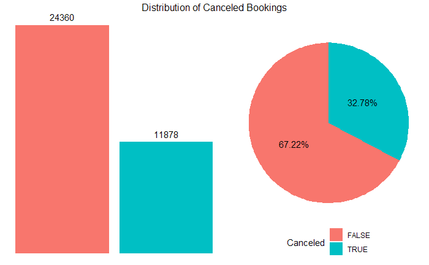

```r
countplot <- ggplot(df, aes(x = canceled, fill = canceled)) +
             geom_bar() +
             geom_text(stat='count', aes(label=after_stat(count)), vjust=-0.64) +
             theme_void() +
             guides(fill = "none")

piechart <- ggplot(df, aes(x = "", fill = canceled)) +
            geom_bar(width = 1) +
            coord_polar(theta = "y") +
            guides(fill = guide_legend(title = "Canceled", ncol = 1)) +
            geom_text(aes(label = paste0(round((after_stat(count))/sum(after_stat(count)) * 100, 2), "%")),
            stat = "count",
            position = position_stack(vjust = 0.5)) +
            theme_void() +
            theme(legend.position = "bottom")

grid.arrange(countplot,
             piechart,
             ncol = 2, widths = c(4, 3.5), top = "Distribution of Canceled Bookings")
```

## 3.2 | Variation of the Average Price per Room

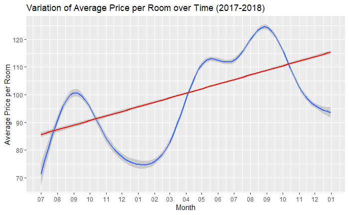

```r
ggplot(df, aes(x = date, y = avg_price_per_room)) +
  geom_smooth(method="auto") +
  geom_smooth(method="lm",color="red")+
  labs(x = "Month", y = "Average Price per Room") +
  ggtitle("Variation of Average Price per Room over Time (2017-2018)") +
  scale_x_date(date_breaks = "1 month", date_labels = "%m")
```

We observe a consistent upward trend in the average room prices over time, with two notable peaks occurring around May-June 2018 and September 2018. In September 2017, there was also a price increase, although it reached a significantly lower peak compared to 2018. Typically, the prices are at their lowest during the early months of the year, from January to mid-February. This chart effectively illustrates the relationship between demand and supply, as prices tend to rise during the summer months and around September due to high demand, while they remain comparatively lower at the beginning of the year due to lower demand.

## 3.3 | Variation of Bookings Count

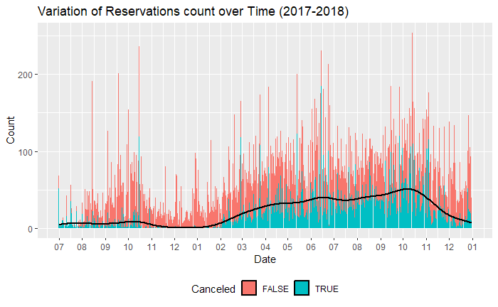

```r
ggplot(df, aes(x = date)) +
  geom_bar(aes(fill = canceled)) +
  geom_density(data = subset(df, canceled == TRUE), aes(y = after_stat(count)),linewidth=0.8)+
  labs(x = "Date", y = "Count", fill = "Canceled") +
  ggtitle("Variation of Reservations count over Time (2017-2018)") +
  theme(legend.position = "bottom")+
  scale_x_date(date_breaks = "1 month", date_labels = "%m")
```

The chart shows the variation of bookings over time, including both canceled and non-canceled reservations. It follows a similar pattern as the average room price variation, which is explained by the variation of Demand all over the year.

## 3.4 | Distribution of Meal Plan Types by Cancellation Status

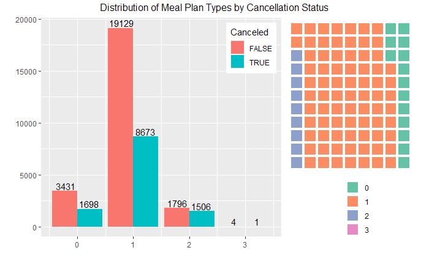

```r
countplot <- ggplot(df, aes(x = type_of_meal_plan, fill = canceled)) +
  geom_bar(position="dodge") +
  labs(x = "", y = "", fill = "Canceled") +
  geom_text(stat='count', aes(label=after_stat(count)),position=position_dodge(width = 0.85), vjust=-0.2) +
  theme(legend.position = c(0.98, 0.98),
        legend.justification = c(1, 1))

wafflechart <- waffle(prop.table(table(df$type_of_meal_plan)) * 100,rows=11,reverse = TRUE,size=1.5, legend_pos = "bottom") +
  theme(legend.direction = "vertical")+
  theme(legend.spacing.y = unit(-0.5,"cm"))

grid.arrange(countplot, wafflechart, ncol = 2, widths = c(2, 1),top="Distribution of Meal Plan Types by Cancellation Status")
```

The majority of bookings either opt for the first meal plan option or do not select any meal plan at all.

## 3.5 | Distribution of Room Types by Cancellation Status

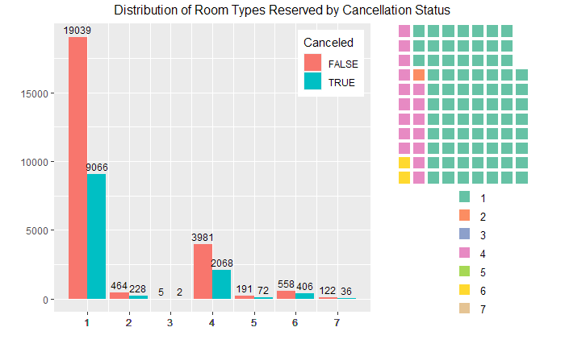

```r
countplot <- ggplot(df, aes(x = room_type_reserved, fill = canceled)) +
  geom_bar(position="dodge") +
  labs(x = "", y = "", fill = "Canceled") +
  geom_text(stat='count', aes(label=after_stat(count)),position=position_dodge(width = 0.9), vjust=-0.5,size =3.1) +
  theme(legend.position = c(0.98, 0.98),
        legend.justification = c(1, 1))+
scale_x_continuous(breaks = df$room_type_reserved)

wafflechart <- waffle(prop.table(table(df$room_type_reserved)) * 100,rows=11,reverse = TRUE,size=1.5, legend_pos = "bottom") +
  theme(legend.direction = "vertical",
        legend.spacing.y = unit(-0.5,"cm"),
        legend.title = element_blank(),
        legend.text = element_text(size = 10)) +
  guides(fill = guide_legend(override.aes = list(size = 3)))

grid.arrange(countplot, wafflechart, ncol = 2, widths = c(2, 1),top="Distribution of Room Types Reserved by Cancellation Status")
```

The majority of clients prefer either the first type of rooms or the fourth type.

## 3.6 | Distribution of Market Segments by Cancellation Status

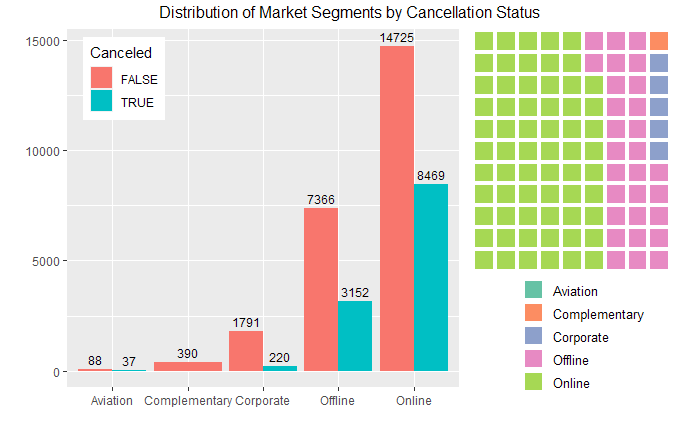

```r
countplot <- ggplot(df, aes(x = market_segment_type, fill = canceled)) +
  geom_bar(position="dodge") +
  labs(x = "", y = "", fill = "Canceled") +
  geom_text(stat='count', aes(label=after_stat(count)),position=position_dodge(width = 0.9), vjust=-0.5,size =3.1) +
  theme(legend.position = c(0.25, 0.98),
        legend.justification = c(1, 1))

wafflechart <- waffle(prop.table(table(df$market_segment_type)) * 100, rows=11, reverse = TRUE, size=1.5, legend_pos = "bottom") +
  theme(legend.direction = "vertical",
        legend.spacing.y = unit(-0.4,"cm"),
        legend.title = element_blank(),
        legend.text = element_text(size = 10),
        panel.grid = element_blank())

grid.arrange(countplot, wafflechart, ncol = 2, widths = c(2, 1),top="Distribution of Market Segments by Cancellation Status")
```

The majority of reservations are made online, followed by offline methods, which is why online bookings have the highest rate of cancellation. It is also worth noting that clients who chose the complementary option did not cancel their bookings once.

## 3.7 | Lead Time

```r
ggplot(df, aes(x = lead_time)) +
  geom_histogram(binwidth = 10,color = "white",fill=custom_blue) +
  labs(x = "Lead Time", y = "Count") +
  ggtitle("Variation of Lead Time")
```

[output not shown]

There is an inverse relationship between the lead time and the number of reservations. As the lead time increases, the number of reservations decreases.

## 3.8 | Number of Children & Adults

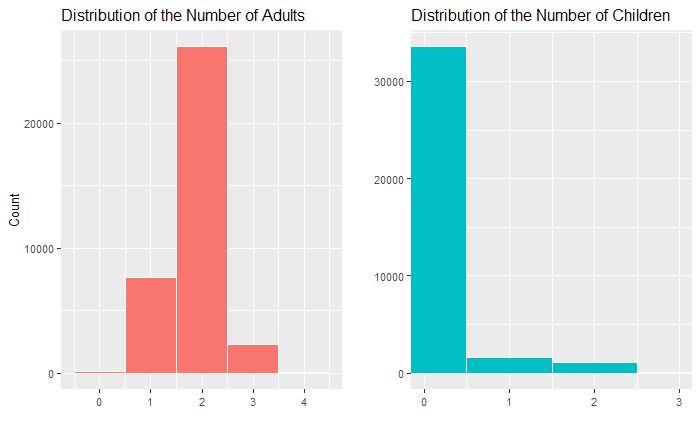

```r
hist_adults <- ggplot(df) +
  geom_histogram(aes(x = no_of_adults),binwidth = 1,color="white",fill=custom_red) +
  labs( y = "Count",x="") +
  ggtitle("Distribution of the Number of Adults") +
  theme(text=element_text(size=10))

hist_children <- ggplot(df) +
  geom_histogram(aes(x = no_of_children),binwidth = 1, color="white",fill=custom_blue) +
  labs(x = "", y = "") +
  coord_cartesian(xlim = c(0, 3)) +
  scale_x_continuous(breaks = seq(0, 10, 1)) +
  ggtitle("Distribution of the Number of Children") +
  theme(text=element_text(size=10))

grid.arrange(hist_adults, hist_children, nrow = 1)
```

The majority of bookings consist of 2 adults and no children.

## 3.9 | Number of Week & Weekend Nights

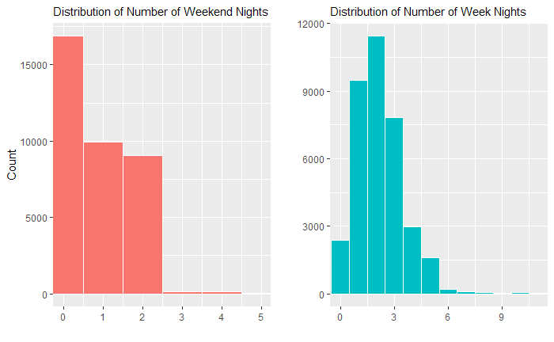

```r
hist_weekend_nights <- ggplot(df) +
  geom_histogram(aes(x = no_of_weekend_nights), binwidth = 1, color = "white",fill=custom_red) +
  labs(y = "Count", x = "") +
  coord_cartesian(xlim = c(0, 5)) +
  ggtitle("Distribution of Number of Weekend Nights") +
  theme(plot.title = element_text(size = 11))

hist_week_nights <- ggplot(df) +
  geom_histogram(aes(x = no_of_week_nights), binwidth = 1, color = "white",fill=custom_blue) +
  labs(x = "", y = "") +
  coord_cartesian(xlim = c(0, 11)) +
  ggtitle("Distribution of Number of Week Nights") +
  theme(plot.title = element_text(size = 11))

grid.arrange(hist_weekend_nights, hist_week_nights, nrow = 1)
```

The analysis reveals that a significant number of bookings have no weekend nights and stay for 1-3 days during the weekdays. Alternatively, there is a considerable portion of reservations that encompass the entire weekend, indicating a preference for longer weekend getaways.

## 3.11 | Distribution of Recurring Customers

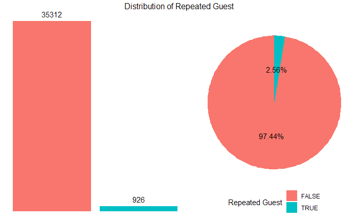

```r
countplot_repeated_guest <- ggplot(df, aes(x = repeated_guest, fill = repeated_guest)) +
  geom_bar() +
  geom_text(stat = 'count', aes(label = after_stat(count)), vjust = -0.64) +
  scale_fill_manual(values = c(custom_red,custom_blue)) +
  theme_void() +
  theme(legend.position = "none")

piechart_repeated_guest <- ggplot(df, aes(x = "", fill = repeated_guest)) +
  geom_bar(width = 1) +
  coord_polar(theta = "y") +
  guides(fill = guide_legend(title = "Repeated Guest", ncol = 1)) +
  geom_text(aes(label = paste0(round((after_stat(count)) / sum(after_stat(count)) * 100, 2), "%")),
            stat = "count",
            position = position_stack(vjust = 0.5)) +
  theme_void() +
  theme(legend.position = "bottom")

grid.arrange(countplot_repeated_guest,
             piechart_repeated_guest,
             ncol = 2, widths = c(4, 3.5), top = "Distribution of Repeated Guest")
```

# 4 | Pre Training

## 4.1 | Indexing Market Segment Type Column

```r
df$market_segment_type <- as.numeric(factor(df$market_segment_type))
head(df["market_segment_type"])
```

|  | market_segment_type |
| --- | --- |
| 1 | 4 |
| 2 | 5 |
| 3 | 5 |
| 4 | 5 |
| 5 | 5 |
| 6 | 5 |

```r
table(df$market_segment_type)
```

```
    1     2     3     4     5
  125   390  2011 10518 23194
```

1 -> Aviation

2 -> Complementary

3 -> Corporate

4 -> Offline

5 -> Online

## 4.2 | Chi-squared Test of Dataset against last Column

```r
p_values <- sapply(results, function(res) res$p.value) # Extract the p-values from the test results
sorted_results <- order(p_values)

for (i in sorted_results) {
  column_name <- names(results)[i]
  p_value <- p_values[i]
  print(paste(column_name, ":", p_value))
}
```

```
[1] "lead_time : 0"
[1] "date : 0"
[1] "avg_price_per_room : 0"
[1] "no_of_special_requests : 0"
[1] "arrival_month : 9.50313824788491e-296"
[1] "arrival_year : 2.0116966764858e-256"
[1] "market_segment_type : 3.86137442529749e-174"
[1] "repeated_guest : 9.71338143834265e-93"
[1] "no_of_week_nights : 1.46459172324772e-81"
[1] "no_of_adults : 1.29772939186777e-71"
[1] "type_of_meal_plan : 3.6161297558052e-60"
[1] "required_car_parking_space : 4.42630429427826e-60"
[1] "arrival_date : 3.22797122518596e-50"
[1] "no_of_previous_bookings_not_canceled : 2.01018270040158e-49"
[1] "no_of_weekend_nights : 4.65590327813187e-44"
[1] "no_of_previous_cancellations : 1.20819888961454e-26"
[1] "no_of_children : 8.05038864082904e-11"
[1] "room_type_reserved : 1.27674962860345e-10"
```

Based on the analysis, it is evident that certain features play a significant role in determining whether a client will cancel their bookings or not.

## 4.3 | Correlation Test

> The date column has been excluded from the dataset as it is not suitable for calculating correlations.

```r
sorted_cor <- sort(cor_df[,"canceled"], decreasing = TRUE)
sorted_cor
```

```
                            canceled                            lead_time
                                1.00                                 0.44
                        arrival_year                  market_segment_type
                                0.18                                 0.14
                  avg_price_per_room                         no_of_adults
                                0.14                                 0.09
                   no_of_week_nights                 no_of_weekend_nights
                                0.09                                 0.06
                   type_of_meal_plan                       no_of_children
                                0.05                                 0.03
                  room_type_reserved                         arrival_date
                                0.02                                 0.01
                       arrival_month         no_of_previous_cancellations
                               -0.01                                -0.03
no_of_previous_bookings_not_canceled           required_car_parking_space
                               -0.06                                -0.09
                      repeated_guest               no_of_special_requests
                               -0.11                                -0.25
```

Based on the correlation calculations, it is evident that “lead_time”, “market_segment_type”, and “avg_price_per_room” exhibit a positive correlation with the target column “canceled”. Conversely, “no_of_special_requests” and “repeated_guest” demonstrate a negative relationship with the target feature. However, it is noteworthy that “type_of_meal_plan”, “arrival_date”, and “arrival_month” show little to no influence on the customer decision to cancel their booking.

# 5 | Training

Since we will be performing binary classification, and for improved results, we will utilize:

- Logistic Regression
- Decision Trees
- Random Forest

```r
# Split data into training and testing sets
set.seed(42)
df$canceled <- factor(df$canceled) # Convert target column to factor
train_indices <- createDataPartition(df$canceled, p = 0.7, list = FALSE)
train_data <- df[train_indices, ]
test_data <- df[-train_indices, ]
```

## 5.1 | Logistic Regression Model

```r
lr_model <- train(canceled ~ ., data = train_data, method = "glm", family = "binomial")
# glm for Generalized Linear Model, framework for linear models
# binomial for binary classification

lr_predictions <- predict(lr_model, newdata = test_data)

confusionMatrix(lr_predictions, test_data$canceled)
```

```
Confusion Matrix and Statistics

          Reference
Prediction FALSE TRUE
     FALSE  6473 1364
     TRUE    835 2199

               Accuracy : 0.7977
                 95% CI : (0.79, 0.8052)
    No Information Rate : 0.6722
    P-Value [Acc > NIR] : < 2.2e-16

                  Kappa : 0.5228

 Mcnemar's Test P-Value : < 2.2e-16

            Sensitivity : 0.8857
            Specificity : 0.6172
         Pos Pred Value : 0.8260
         Neg Pred Value : 0.7248
             Prevalence : 0.6722
         Detection Rate : 0.5954
   Detection Prevalence : 0.7209
      Balanced Accuracy : 0.7515

       'Positive' Class : FALSE
```

## 5.2 | Decision Tree Model

```r
dt_model <- rpart(canceled ~ ., data = train_data, method = "class")
# class method to build a decision tree for classification

dt_predictions <- predict(dt_model, newdata = test_data, type = "class")
# class type to show classes not probabilities

confusionMatrix(dt_predictions, test_data$canceled)
```

```
Confusion Matrix and Statistics

          Reference
Prediction FALSE TRUE
     FALSE  6581 1158
     TRUE    727 2405

               Accuracy : 0.8266
                 95% CI : (0.8194, 0.8337)
    No Information Rate : 0.6722
    P-Value [Acc > NIR] : < 2.2e-16

                  Kappa : 0.5939

 Mcnemar's Test P-Value : < 2.2e-16

            Sensitivity : 0.9005
            Specificity : 0.6750
         Pos Pred Value : 0.8504
         Neg Pred Value : 0.7679
             Prevalence : 0.6722
         Detection Rate : 0.6054
   Detection Prevalence : 0.7119
      Balanced Accuracy : 0.7878

       'Positive' Class : FALSE
```

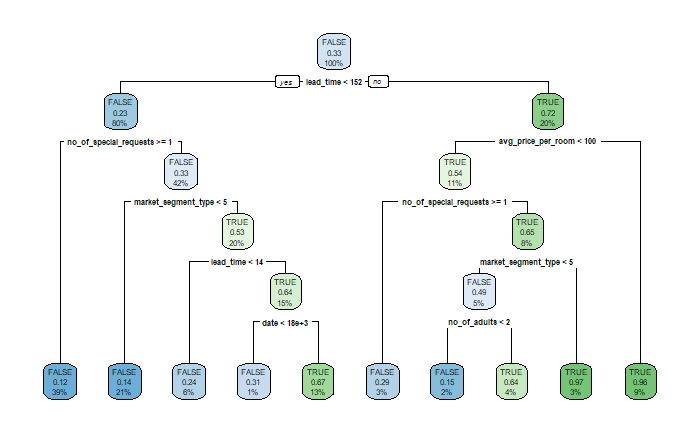

```r
rpart.plot(dt_model) # Show decison tree
```

## 5.3 | Random Forest Model

```r
rf_model <- randomForest(canceled ~ ., data = train_data)
rf_predictions <- predict(rf_model, newdata = test_data)

confusionMatrix(rf_predictions, test_data$canceled)
```

```
Confusion Matrix and Statistics

          Reference
Prediction FALSE TRUE
     FALSE  6881  654
     TRUE    427 2909

               Accuracy : 0.9006
                 95% CI : (0.8948, 0.9061)
    No Information Rate : 0.6722
    P-Value [Acc > NIR] : < 2.2e-16

                  Kappa : 0.7706

 Mcnemar's Test P-Value : 6.252e-12

            Sensitivity : 0.9416
            Specificity : 0.8164
         Pos Pred Value : 0.9132
         Neg Pred Value : 0.8720
             Prevalence : 0.6722
         Detection Rate : 0.6330
   Detection Prevalence : 0.6931
      Balanced Accuracy : 0.8790

       'Positive' Class : FALSE
```

# 6 | Model Evaluation

```r
lr_accuracy <- confusionMatrix(lr_predictions, test_data$canceled)$overall['Accuracy']
dt_accuracy <- confusionMatrix(dt_predictions, test_data$canceled)$overall['Accuracy']
rf_accuracy <- confusionMatrix(rf_predictions, test_data$canceled)$overall['Accuracy']
```

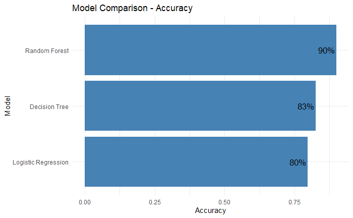

```r
# Store the accuracy scores in a data frame
accuracy_df <- data.frame(Model = c("Logistic Regression", "Decision Tree", "Random Forest"),
                          Accuracy = c(lr_accuracy, dt_accuracy, rf_accuracy))

# Sort the data frame by accuracy in descending order
accuracy_df <- accuracy_df[order(accuracy_df$Accuracy, decreasing = TRUE), ]

# Create the bar plot
ggplot(accuracy_df, aes(x = Accuracy, y = reorder(Model, Accuracy))) +
  geom_bar(stat = "identity", fill = "steelblue") +
  labs(x = "Accuracy", y = "Model", title = "Model Comparison - Accuracy") +
  theme_minimal() +
  geom_text(aes(label = paste0(round(Accuracy * 100), "%")), hjust =1.1, size = 4.5)
```

The performance evaluation of the different models indicates that Random Forest achieved the highest accuracy score of 90%, followed by Decision Tree with a score of 83%, and logistic regression with a score of 80%.